# Markov Model with transition costs (Willits 2012)

Cost impact of the WatchBP Home A used in primary healthcare

Andrew J. Sims

May 2021

# Introduction

This vignette describes a Markov model that was used to evaluate the cost consequences of opportunistic screening for atrial fibrillation (AF) during clinic visits involving blood pressure measurement. It was first developed for the assessment of the WatchBP oscillometric blood pressure measurement device by the National Institute of Health and Care Excellence (NICE)<sup>1</sup> and is described fully in a report that was published during the guidance development process.<sup>2</sup>

The guidance report followed two cohorts, those aged 65-74 and those aged 75-84, to account for the age dependency in risk of AF. This vignette focuses on the older cohort.

# Diagnostic phase

The diagnostic phase was modelled as a decision tree in which the diagnostic test accuracies of the index technology (WatchBP) and the comparator technology (pulse palpation) were used to estimate the proportions of the cohort falling into the true positive (TP), true negative (TN), false positive (FP) and false negative (FN) categories. These proportions were used to define the starting populations in the management phase (a Markov model) with a cohort size of 10^{5}. In the diagnostic phase the prevalance of AF was 0.072; WatchBP had a sensitivity of 0.967 and a specificity of 0.888; pulse palpation had a sensitivity of 0.872 and a specificity of 0.813.

The number of patients predicted to be in each of the four categories for each test is shown in the table below.

| Leaf | Test | Population |
| --- | --- | --- |
| TP | WatchBP | 6962 |
| FP | WatchBP | 10394 |
| FN | WatchBP | 237.6 |
| TN | WatchBP | 82406 |
| TP | PP | 6278 |
| FP | PP | 17354 |
| FN | PP | 921.6 |
| TN | PP | 75446 |

# Management phase

## Model structure

A Markov model was constructed with six states (Fig 1): AF, GI bleed, stroke (year 1), stroke (subsequent years), fatal stroke and dead. The GI bleed state was a tunnel state, which patients occupied for 1 cycle before returning to the AF state. Patients in this state have AF, and thus the same risk of stroke and death as patients in the AF state. The fatal stroke and dead states were absorbing states. The stroke in year 1 had no self loop and thus a maximum occupancy of 1 cycle. The transition rates and costs that will be set for each cohort are set to zero when each edge is created.

```r
# AF state
AF <- MarkovState$new("AF")
# disease states
GB <- MarkovState$new("GIbleed")
S1 <- MarkovState$new("StrokeY1")
SN <- MarkovState$new("StrokeY2+")
SF <- MarkovState$new("FatalStroke")
DD <- MarkovState$new("Dead")
# transitions from AF
e.AFAF <- MarkovTransition$new(AF, AF, r=NULL)
e.AFGB <- MarkovTransition$new(AF, GB, r=0)
e.AFDD <- MarkovTransition$new(AF, DD, r=0)
e.AFS1 <- MarkovTransition$new(AF, S1, r=0, cost=1)
# transitions from GI bleed
e.GBAF <- MarkovTransition$new(GB, AF, r=NULL)
e.GBS1 <- MarkovTransition$new(GB, S1, r=0)
e.GBDD <- MarkovTransition$new(GB, DD, r=0)
# transitions from stroke, year 1
e.S1SN <- MarkovTransition$new(S1, SN, r=NULL)
e.S1SF <- MarkovTransition$new(S1, SF, r=0)
e.S1DD <- MarkovTransition$new(S1, DD, r=0)
# transitions from stroke, subsequent years
e.SNSN <- MarkovTransition$new(SN, SN, r=NULL)
e.SNSF <- MarkovTransition$new(SN, SF, r=0)
e.SNDD <- MarkovTransition$new(SN, DD, r=0)
# transitions from absorbing states
e.DDDD <- MarkovTransition$new(DD, DD)
e.SFSF <- MarkovTransition$new(SF, SF)
# create model
CM <- CohortMarkovModel$new(
  V = list(AF, GB, DD, S1, SN, SF),
  E = list(e.AFAF, e.AFGB, e.AFDD, e.AFS1, e.GBAF, e.GBDD, e.GBS1,
           e.S1SF, e.S1SN, e.S1DD,
           e.SNSN, e.SNSF, e.SNDD, e.DDDD, e.SFSF),
  hcc = FALSE,
  tcycle = as.difftime(365.25/12, units="days")
)
```

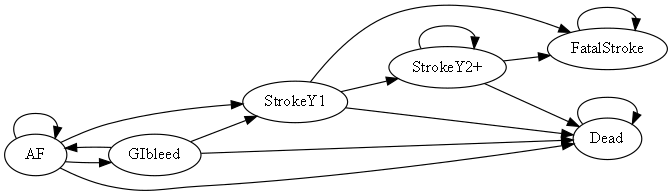

Figure 1. Markov model for management of atrial fibrillation

## Cohorts

The model was run for several sub-cohorts, each defined by their CHADS2 score and medication. The variables used in the model were: the annual probability of a major GI bleed due to aspirin or oral anticoagulant medication (`pB`); the annual probability of a stroke, based on CHADS2 risk (`pS`); the annual probability of death due to all causes (`SMR`) for the age at the centre of the range; the proportion of strokes that are fatal in the first year (`pF1`); the proportion of strokes that are fatal in subsequent years (`pFN`) and the relative risk of stroke associated with medication (`rr.S`). These are shown in the table below (probabilities shown as percentages).

Characteristics of each sub-cohort.

| CHADS2 | Tx | pB | pS | SMR | pF1 | pFN | rr.S |
| --- | --- | --- | --- | --- | --- | --- | --- |
| 1 | Aspirin | 1.6 | 2.8 | 5.93 | 36.5 | 10 | 0.78 |
| 1 | Anticoagulant | 1.4 | 2.8 | 5.93 | 36.5 | 10 | 0.32 |
| 2 | Anticoagulant | 1.4 | 4 | 5.93 | 36.5 | 10 | 0.32 |
| 3 | Anticoagulant | 1.4 | 5.9 | 5.93 | 36.5 | 10 | 0.32 |
| 4 | Anticoagulant | 1.4 | 8.5 | 5.93 | 36.5 | 10 | 0.32 |
| 5 | Anticoagulant | 1.4 | 12.5 | 5.93 | 36.5 | 10 | 0.32 |
| 6 | Anticoagulant | 1.4 | 18.2 | 5.93 | 36.5 | 10 | 0.32 |

## An example cohort

```r
idx <- 4
e.AFGB$set_rate(-log(1-COHORT[idx,"pB"]/100))
e.AFDD$set_rate(-log(1-COHORT[idx,"SMR"]/100))
p.stroke <- (COHORT[idx,"pS"]/100) * COHORT[idx,"rr.S"]
r.stroke <- -log(1-p.stroke)/1
e.AFS1$set_rate(r.stroke)
e.GBS1$set_rate(r.stroke)
e.GBDD$set_rate(-log(1-COHORT[idx,"SMR"]/100))
e.S1SF$set_rate(-log(1-COHORT[idx,"pF1"]/100))
e.S1DD$set_rate(-log(1-COHORT[idx,"SMR"]/100))
e.SNSF$set_rate(-log(1-COHORT[idx,"pFN"]/100))
e.SNDD$set_rate(-log(1-COHORT[idx,"SMR"]/100))
```

Table continues below

|  | AF | GIbleed | Dead | StrokeY1 | StrokeY2+ |
| --- | --- | --- | --- | --- | --- |
| AF | 0.9922 | 0.001174 | 0.005081 | 0.001587 | 0 |
| GIbleed | 0.9933 | 0 | 0.005081 | 0.001587 | 0 |
| Dead | 0 | 0 | 1 | 0 | 0 |
| StrokeY1 | 0 | 0 | 0.005081 | 0 | 0.9578 |
| StrokeY2+ | 0 | 0 | 0.005081 | 0 | 0.9862 |
| FatalStroke | 0 | 0 | 0 | 0 | 0 |

|  | FatalStroke |  |
| --- | --- | --- |
| AF | 0 | 1 |
| GIbleed | 0 | 1 |
| Dead | 0 | 1 |
| StrokeY1 | 0.03714 | 1 |
| StrokeY2+ | 0.008742 | 1 |
| FatalStroke | 1 | 1 |

Over ten years, the Markov trace is as follows:

Table continues below

| Cycle | Cost | AF | GIbleed | Dead | StrokeY1 | StrokeY2+ |
| --- | --- | --- | --- | --- | --- | --- |
| 0 | 0 | 1e+05 | 0 | 0 | 0 | 0 |
| 1 | 0.001587 | 99216 | 117.4 | 508.1 | 158.7 | 0 |
| 2 | 0.001575 | 98554 | 116.5 | 1014 | 157.7 | 152 |
| 3 | 0.001564 | 97897 | 115.7 | 1517 | 156.6 | 300.9 |
| 4 | 0.001554 | 97244 | 115 | 2017 | 155.6 | 446.7 |
| 5 | 0.001543 | 96596 | 114.2 | 2515 | 154.5 | 589.6 |
| 6 | 0.001533 | 95952 | 113.4 | 3010 | 153.5 | 729.4 |
| 7 | 0.001523 | 95312 | 112.7 | 3503 | 152.5 | 866.3 |
| 8 | 0.001513 | 94676 | 111.9 | 3993 | 151.4 | 1000 |
| 9 | 0.001503 | 94045 | 111.2 | 4480 | 150.4 | 1132 |
| 10 | 0.001493 | 93418 | 110.4 | 4965 | 149.4 | 1260 |
| 11 | 0.001483 | 92795 | 109.7 | 5447 | 148.4 | 1386 |
| 12 | 0.001473 | 92176 | 109 | 5927 | 147.5 | 1509 |
| 13 | 0.001463 | 91561 | 108.2 | 6405 | 146.5 | 1629 |
| 14 | 0.001453 | 90951 | 107.5 | 6880 | 145.5 | 1747 |
| 15 | 0.001443 | 90344 | 106.8 | 7352 | 144.5 | 1862 |
| 16 | 0.001434 | 89742 | 106.1 | 7822 | 143.6 | 1975 |
| 17 | 0.001424 | 89143 | 105.4 | 8289 | 142.6 | 2085 |
| 18 | 0.001415 | 88549 | 104.7 | 8754 | 141.6 | 2193 |
| 19 | 0.001405 | 87958 | 104 | 9216 | 140.7 | 2298 |
| 20 | 0.001396 | 87372 | 103.3 | 9676 | 139.8 | 2401 |
| 21 | 0.001387 | 86789 | 102.6 | 10133 | 138.8 | 2502 |
| 22 | 0.001377 | 86211 | 101.9 | 10588 | 137.9 | 2600 |
| 23 | 0.001368 | 85636 | 101.2 | 11041 | 137 | 2696 |
| 24 | 0.001359 | 85065 | 100.6 | 11491 | 136.1 | 2790 |
| 25 | 0.00135 | 84497 | 99.88 | 11938 | 135.2 | 2882 |
| 26 | 0.001341 | 83934 | 99.22 | 12384 | 134.3 | 2972 |
| 27 | 0.001332 | 83374 | 98.56 | 12826 | 133.4 | 3059 |
| 28 | 0.001323 | 82818 | 97.9 | 13267 | 132.5 | 3145 |
| 29 | 0.001314 | 82266 | 97.25 | 13705 | 131.6 | 3228 |

[output cut: 92 more lines]

| FatalStroke | Years | QALY |
| --- | --- | --- |
| 0 | 0 | 0 |
| 0 | 0.08333 | 0.08333 |
| 5.894 | 0.1667 | 0.08333 |
| 13.08 | 0.25 | 0.08333 |
| 21.52 | 0.3333 | 0.08333 |
| 31.21 | 0.4167 | 0.08333 |
| 42.1 | 0.5 | 0.08333 |
| 54.17 | 0.5833 | 0.08333 |
| 67.41 | 0.6667 | 0.08333 |
| 81.78 | 0.75 | 0.08333 |
| 97.26 | 0.8333 | 0.08333 |
| 113.8 | 0.9167 | 0.08333 |
| 131.4 | 1 | 0.08333 |
| 150.1 | 1.083 | 0.08333 |
| 169.8 | 1.167 | 0.08333 |
| 190.5 | 1.25 | 0.08333 |
| 212.1 | 1.333 | 0.08333 |
| 234.7 | 1.417 | 0.08333 |
| 258.2 | 1.5 | 0.08333 |
| 282.7 | 1.583 | 0.08333 |
| 308 | 1.667 | 0.08333 |
| 334.2 | 1.75 | 0.08333 |
| 361.2 | 1.833 | 0.08333 |
| 389 | 1.917 | 0.08333 |
| 417.7 | 2 | 0.08333 |
| 447.1 | 2.083 | 0.08333 |
| 477.3 | 2.167 | 0.08333 |
| 508.3 | 2.25 | 0.08333 |
| 540 | 2.333 | 0.08333 |
| 572.4 | 2.417 | 0.08333 |

[output cut: 92 more lines]

| Years | GIbleed | Stroke | FatalStroke |
| --- | --- | --- | --- |
| 0 | 0 | 0 | 0 |
| 0.08333 | 117.4 | 158.7 | 0 |
| 0.1667 | 233.9 | 316.4 | 5.894 |
| 0.25 | 349.6 | 473 | 13.08 |
| 0.3333 | 464.6 | 628.5 | 21.52 |
| 0.4167 | 578.8 | 783 | 31.21 |
| 0.5 | 692.2 | 936.5 | 42.1 |
| 0.5833 | 804.9 | 1089 | 54.17 |
| 0.6667 | 916.8 | 1240 | 67.41 |
| 0.75 | 1028 | 1391 | 81.78 |
| 0.8333 | 1138 | 1540 | 97.26 |
| 0.9167 | 1248 | 1689 | 113.8 |
| 1 | 1357 | 1836 | 131.4 |
| 1.083 | 1465 | 1983 | 150.1 |
| 1.167 | 1573 | 2128 | 169.8 |
| 1.25 | 1680 | 2273 | 190.5 |
| 1.333 | 1786 | 2416 | 212.1 |
| 1.417 | 1891 | 2559 | 234.7 |
| 1.5 | 1996 | 2700 | 258.2 |
| 1.583 | 2100 | 2841 | 282.7 |
| 1.667 | 2203 | 2981 | 308 |
| 1.75 | 2306 | 3120 | 334.2 |
| 1.833 | 2407 | 3258 | 361.2 |
| 1.917 | 2509 | 3395 | 389 |
| 2 | 2609 | 3531 | 417.7 |
| 2.083 | 2709 | 3666 | 447.1 |
| 2.167 | 2808 | 3800 | 477.3 |
| 2.25 | 2907 | 3934 | 508.3 |
| 2.333 | 3005 | 4066 | 540 |
| 2.417 | 3102 | 4198 | 572.4 |

[output cut: 91 more lines]

# References

1

Willits I, Keltie K, Craig J, Sims A. WatchBP Home A for Opportunistically Detecting Atrial Fibrillation During Diagnosis and Monitoring of Hypertension: A NICE Medical Technology Guidance. *Applied Health Economics and Health Policy* 2014;**12**:255–65. https://doi.org/10.1007/s40258-014-0096-7.

2

Willits I, Keltie K, Craig J, Sims AJ. *Cost impact of the WatchBP Home A used in a primary healthcare clinic environment*. National Institute for Health and Care Excellence; 2012.